# PR02 Streaming Services Data

Abigail Branco, Cat Tinsley, Brandon Chauncey

Thursday, May 11, 2023 @ 12:46 PM

## Setup

### Packages Used

```r
library(tidyverse)
library(dplyr)
library(skimr)
```

### Background of the Data

Two files containing data about thge content of streaming services were downloaded from Kaggle: [Disney+ Movies and TV Shows](https://www.kaggle.com/datasets/shivamb/disney-movies-and-tv-shows) and [TV shows on Netflix, Prime Video, Hulu and Disney+](https://www.kaggle.com/datasets/ruchi798/tv-shows-on-netflix-prime-video-hulu-and-disney). You can read about them there, including variable definitions, sources, when they were created, and other information. Read the two datasets from the `data_raw` folder and use `skim()` to explore their structures.

#### Disney+ Content Dataset

```r
disneydata <- read.csv("../data_raw/disneypluscontent_2021_11_21.csv")
```

```r
skim(disneydata)
```

Data summary

| Name | disneydata |
| --- | --- |
| Number of rows | 1450 |
| Number of columns | 12 |
| _______________________ |  |
| Column type frequency: |  |
| character | 11 |
| numeric | 1 |
| ________________________ |  |
| Group variables | None |

**Variable type: character**

| skim_variable | n_missing | complete_rate | min | max | empty | n_unique | whitespace |
| --- | --- | --- | --- | --- | --- | --- | --- |
| show_id | 0 | 1 | 2 | 5 | 0 | 1450 | 0 |
| type | 0 | 1 | 5 | 7 | 0 | 2 | 0 |
| title | 0 | 1 | 2 | 79 | 0 | 1450 | 0 |
| director | 0 | 1 | 0 | 51 | 473 | 610 | 0 |
| cast | 0 | 1 | 0 | 112 | 190 | 1194 | 0 |
| country | 0 | 1 | 0 | 137 | 219 | 90 | 0 |
| date_added | 0 | 1 | 0 | 9 | 3 | 168 | 0 |
| rating | 0 | 1 | 0 | 8 | 3 | 10 | 0 |
| duration | 0 | 1 | 5 | 10 | 0 | 158 | 0 |
| listed_in | 0 | 1 | 4 | 49 | 0 | 329 | 0 |
| description | 0 | 1 | 28 | 102 | 0 | 1448 | 0 |

**Variable type: numeric**

| skim_variable | n_missing | complete_rate | mean | sd | p0 | p25 | p50 | p75 | p100 | hist |
| --- | --- | --- | --- | --- | --- | --- | --- | --- | --- | --- |
| release_year | 0 | 1 | 2003.09 | 21.86 | 1928 | 1999 | 2011 | 2018 | 2021 | ▁▁▁▂▇ |

#### Streaming TV Content Dataset

```r
streamingdata <- read.csv("../data_raw/streamingtvcontent_2021.csv")
```

```r
skim(streamingdata)
```

Data summary

| Name | streamingdata |
| --- | --- |
| Number of rows | 5368 |
| Number of columns | 10 |
| _______________________ |  |
| Column type frequency: |  |
| character | 4 |
| numeric | 6 |
| ________________________ |  |
| Group variables | None |

**Variable type: character**

| skim_variable | n_missing | complete_rate | min | max | empty | n_unique | whitespace |
| --- | --- | --- | --- | --- | --- | --- | --- |
| Title | 0 | 1 | 1 | 77 | 0 | 5368 | 0 |
| Age | 0 | 1 | 0 | 3 | 2127 | 6 | 0 |
| IMDb | 0 | 1 | 0 | 6 | 962 | 79 | 0 |
| Rotten.Tomatoes | 0 | 1 | 6 | 7 | 0 | 85 | 0 |

**Variable type: numeric**

| skim_variable | n_missing | complete_rate | mean | sd | p0 | p25 | p50 | p75 | p100 | hist |
| --- | --- | --- | --- | --- | --- | --- | --- | --- | --- | --- |
| ID | 0 | 1 | 2814.95 | 1672.39 | 1 | 1345.75 | 2788 | 4308.25 | 5717 | ▇▇▇▇▇ |
| Year | 0 | 1 | 2012.63 | 10.14 | 1904 | 2011.00 | 2016 | 2018.00 | 2021 | ▁▁▁▁▇ |
| Netflix | 0 | 1 | 0.37 | 0.48 | 0 | 0.00 | 0 | 1.00 | 1 | ▇▁▁▁▅ |
| Hulu | 0 | 1 | 0.30 | 0.46 | 0 | 0.00 | 0 | 1.00 | 1 | ▇▁▁▁▃ |
| Prime.Video | 0 | 1 | 0.34 | 0.47 | 0 | 0.00 | 0 | 1.00 | 1 | ▇▁▁▁▅ |
| Disney. | 0 | 1 | 0.07 | 0.25 | 0 | 0.00 | 0 | 0.00 | 1 | ▇▁▁▁▁ |

## Analyses

### Clean, Tidy, and Save the Data

#### Dataset #1: Disney+ Data

The Disney+ dataset contains a variable that gives information about the `rating` for each program offering. Convert that variable into a factor that puts the ratings in (roughly) ascending order of age restriction/audience: `TV-Y`, `TV-Y7`, `TV-Y7-FV`, `TV-G`, `G`, `TV-PG`, `PG`, `PG-13`, `TV-14`. Delete the `show_id`, `director`, `cast`, and `description` variables. You should be able to do this all in one piped sequence.

```r
disneydata <- disneydata %>%
  mutate(rating = factor(rating, levels = c("TV-Y", "TV-Y7", "TV-Y7-FV", "TV-G", "G", "TV-PG", "PG", "PG-13", "TV-14"))) %>%
  select(-c("show_id", "director", "cast", "description"))
```

#### Dataset #2: Streaming TV Data

Perform the following manipulations to tidy the streaming TV data for analysis. You should be able to do this all in one piped sequence.

- Pivot the `Netflix`, `Hulu`, `Prime Video`, and `Disney+` variables into two columns called `Service` (containing the name of the streaming service) and `YesNo` (containing the 0/1 values from the original columns).
- Filter the dataset to remove any row where `YesNo == 0` (i.e., a show is *not* on the service).
- Separate the `IMDb` variable to split each show’s actual rating from the maximum possible rating of `10`.
- Convert the show’s actual IMDB rating into a numerical variable and get rid of the column containing `10`.
- Separate the `Rotten Tomatoes` variable to split each show’s actual rating from the maximum possible rating of `100`.
- Convert the show’s actual Rotten Tomatoes rating into a numerical variable and get rid of the column containing `100`.

```r
streamingdata_ <- streamingdata %>%
  pivot_longer(cols = c(Netflix, Hulu, Prime.Video, Disney.), names_to = "Service", values_to = "YesNo") %>%
  filter(YesNo == 1) %>%
  separate(IMDb, into = c("IMDb_rating", "IMDb_max"), sep = "/") %>%
  mutate(IMDb_rating = as.numeric(IMDb_rating)) %>%
  select(-IMDb_max) %>%
  separate(`Rotten.Tomatoes`, into = c("RottenTomatoes_rating", "RottenTomatoes_max"), sep = "/") %>%
  mutate(RottenTomatoes_rating = as.numeric(RottenTomatoes_rating)) %>%
  select(-RottenTomatoes_max)
```

#### Save the Formatted Data Files

Save both data files in a single`.RData` file in the `data_tidy` folder.

```r
save(streamingdata, file = "../data_tidy/streamingcontent.RData")
save(disneydata, file = "../data_tidy/streamingcontent.RData")
```

### Analysis 1: Disney Content & Release Years

**This analysis uses Dataset #1.**

#### Release Years by Program Type—Plot #1

Create a violin plot of `release_year` (x axis) grouped by `type` of program (y axis) for programs on Disney+. Add a boxplot inside the violin plot. Re-scale the X axis so that tick marks appear at whole-decade intervals (e.g., 1980, 1990, 2000). Include an informative title and axis labels. Add at least two other types of formatting to enhance the effectiveness and/or appearance of your plot (e.g., themes, colors, etc).

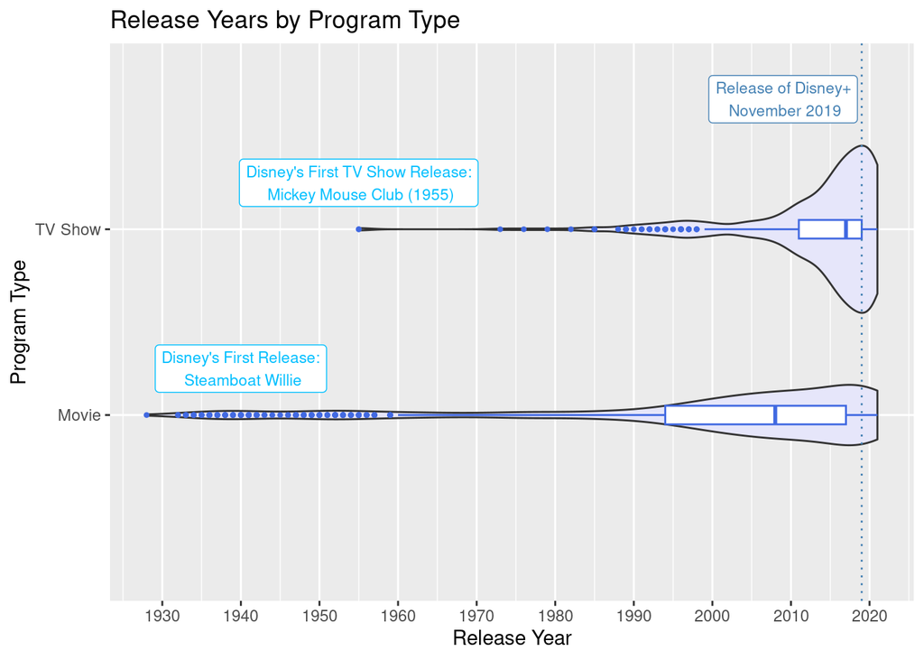

```r
ggplot(disneydata, aes(release_year, type)) +
  geom_violin(fill = "lavender") +
  geom_boxplot(width = .1, color = "royalblue", outlier.size = .8) +
  labs(title = "Release Years by Program Type",
       x = "Release Year",
       y = "Program Type") +
  scale_x_continuous(breaks = seq(1920, 2030, 10)) +
  annotate("label", x = 1955, y = 2.25, label = "Disney's First TV Show Release:\n Mickey Mouse Club (1955)", size = 3, color = "deepskyblue", fill = "white") +
  annotate("label", x = 2009, y = 2.7, label = "Release of Disney+\n November 2019", size = 3, color = "steelblue") +
  annotate("segment", x = 2019, xend = 2019, y = 0, yend = 3, color = "steelblue", linetype = "dotted") +
  annotate("label", x = 1940, y = 1.25, label = "Disney's First Release:\n Steamboat Willie", size = 3, color = "deepskyblue", fill = "white")
```

#### Release Years by Program Type—Plot #2

Create a histogram for `release_year` with `type` as a fill variable. Choose a reasonable number of bins or bin width. Re-scale the X axis so that tick marks appear at whole-decade intervals (e.g., 1980, 1990, 2000). Scale the Y axis to have reasonably spaced tick marks. Add vertical lines with annotations to indicate the debuts of the Disney Brothers Cartoon Studio (1923), the Disney Channel on TV (1983), and Disney+ streaming service (2019). Include an informative title and axis labels. Delete the title “type” from the legend. Add at least two other types of formatting to enhance the effectiveness and/or appearance of your plot (e.g., themes, colors, etc).

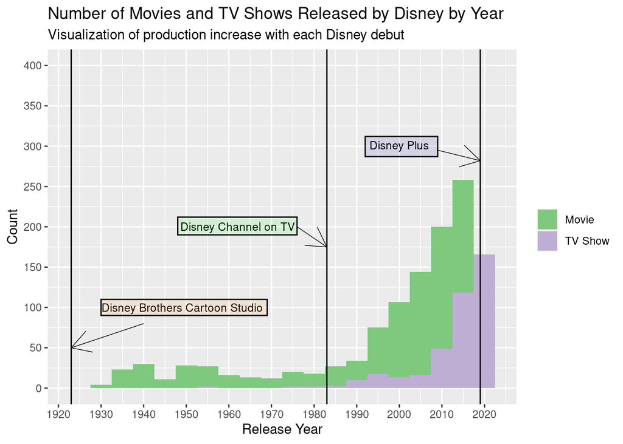

```r
ggplot(disneydata, aes(x = release_year, fill = type)) +
  geom_histogram(binwidth = 5) + scale_fill_brewer(palette = "Accent") +
  scale_x_continuous(breaks = seq(1920, 2020, 10)) +
  scale_y_continuous(breaks = seq(0, 400, 50), limits = c(0, 400)) +
  labs(title = "Number of Movies and TV Shows Released by Disney by Year",
       x = "Release Year",
       y = "Count",
       subtitle = "Visualization of production increase with each Disney debut") +
  geom_vline(xintercept = 1923) +
    annotate("text", x = 1949, y = 100, label = "Disney Brothers Cartoon Studio", size = 3.2) +
    annotate("segment", x = 1940, xend = 1923, y = 80, yend = 50,
           colour = "black", size = .25, arrow = arrow()) +
    annotate("rect", xmin = 1930, xmax = 1969, ymin = 90, ymax = 110,
           alpha = .1,fill = "dark orange", colour = "black") +
  geom_vline(xintercept = 1983) +
    annotate("text", x = 1962, y = 200, label = "Disney Channel on TV", size = 3.2) +
    annotate("segment", x = 1976, xend = 1983, y = 200, yend = 175,
           colour = "black", size = .25, arrow = arrow()) +
    annotate("rect", xmin = 1948, xmax = 1976, ymin = 190, ymax = 212,
           alpha = .1,fill = "green", colour = "black") +
  geom_vline(xintercept = 2019) +
    annotate("text", x = 2000, y = 301, label = "Disney Plus", size = 3.2) +
    annotate("segment", x = 2009, xend = 2019, y = 295, yend = 282,
           colour = "black", size = .25, arrow = arrow()) +
    annotate("rect", xmin = 1992, xmax = 2009, ymin = 287, ymax = 312,
           alpha = .1,fill = "dark blue", colour = "black") +
  theme(legend.title = element_blank())
```

#### Release Years by Program Type—Summary

Create a quantitative summary of `release_year` by program `type` that shows the oldest release year, the median release year, and the newest release year for each group of programs (i.e., movies and TV shows).

```r
summary <- disneydata %>%
  group_by(type) %>%
  summarize(oldest = min(release_year),
            median = median(release_year),
            newest = max(release_year))
summary
```

```
# A tibble: 2 × 4
  type    oldest median newest
  <chr>    <int>  <dbl>  <int>
1 Movie     1928   2008   2021
2 TV Show   1955   2017   2021
```

### Analysis 2: Disney Content & Ratings

**This analysis uses Dataset #1.**

Create a horizontal barplot to show the frequencies of the various `rating` categories for programs on Disney+ (i.e., use `y =` rather than `x =` for the variable you are plotting). **You will need to remove a couple `NA` values before plotting** Facet by `type` so that you have side-by-side plots for the two different program types. Add an informative title and axis labels, as well as at least two other types of useful formatting.

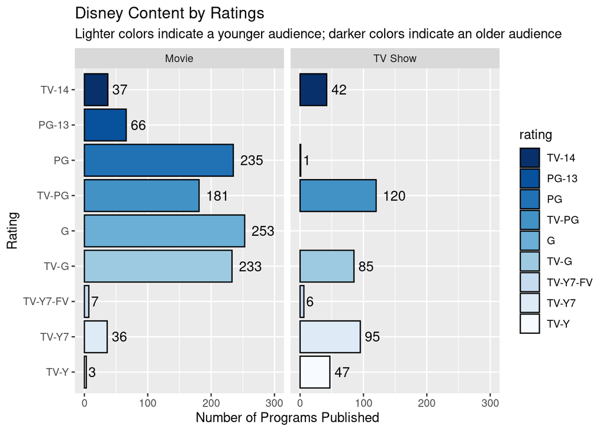

```r
disneydata %>%
  na.omit() %>%
  ggplot(aes(y = rating, fill = rating)) +
         geom_bar(colour = "black") +
  facet_wrap(~type) +
  labs(title = "Disney Content by Ratings",
       subtitle = "Lighter colors indicate a younger audience; darker colors indicate an older audience",
       x = "Number of Programs Published",
       y = "Rating") +
  theme(legend.title = element_blank()) +
  geom_text(aes(label = after_stat(count)), stat = "count", hjust = -.3, colour = "black", size = 4) +
  xlim(0, 300) +
    scale_fill_brewer(palette = "Blues", breaks=c('TV-14', 'PG-13', 'PG', 'TV-PG', 'G', 'TV-G', 'TV-Y7-FV', 'TV-Y7', 'TV-Y')) +
theme_gray()
```

### Analysis 3: Content on Different Services

**This analysis uses Dataset #2.**

#### Quantity of Content by Service

Create an appropriate barplot to show the number of TV shows offered by the four streaming services. Include an informative title and axis labels. Add at least two other types of formatting to enhance the effectiveness and/or appearance of your plot (e.g., themes, colors, etc).

[figure not shown]

```r
num.tvshows <- streamingdata_ %>%
  filter(YesNo == 1) %>%
  group_by(Service) %>%
  summarize(count = n())
ggplot(num.tvshows, aes(x = reorder(Service, count), y = count, fill = Service)) +
  geom_col(position = "dodge", colour = "white") +
  geom_text(
    aes(label = count),
    colour = "white", size = 5,
    vjust = 1.5, position = position_dodge(.9)) +
  theme_classic() +
  labs(title = "Number of TV Shows by Streaming Service", x = "Streaming Service", y = "Number of TV Shows") +
  scale_y_continuous(breaks = seq(0, 2000, by = 200)) +
  scale_x_discrete(labels = c("Netflix", "Hulu", "Disney+", "Prime Video")) +
  scale_fill_discrete(labels = c("Netflix", "Hulu", "Disney+", "Prime Video"))
```

#### Quality of Content by Service

Create an appropriate plot to compare either IMDB or Rotten Tomatoes ratings for content on the streaming services. Include an informative title and axis labels. Add at least two other types of formatting to enhance your plot (e.g., themes, colors, etc).

[figure not shown]

```r
ggplot(streamingdata_, aes(x = Service, y = IMDb_rating, color = Service)) +
  geom_jitter(width = 0.2, height = 0, alpha = 0.7) +
  geom_boxplot(width = .1, color = "black", outlier.size = 1) +
  labs(title = "Comparison of IMDb Ratings on Streaming Services",
       x = "Streaming Service",
       y = "IMDb Rating") +
  theme_bw() +
  scale_x_discrete(labels = c("Netflix", "Hulu", "Disney+", "Prime Video")) +
  scale_color_discrete(labels = c("Netflix", "Hulu", "Disney+", "Prime Video"))
```

### Analysis 4: Choose Your Own Plot!

**This plot uses either dataset.**

Create one other plot of your choice using either dataset to explore a question of interest. It should not be too similar to any of the plots you made above. You are welcome to perform additional manipulations on the data, if needed. Add an appropriate title and axis labels, as well as any other necessary formatting to make your plot clear and effective.

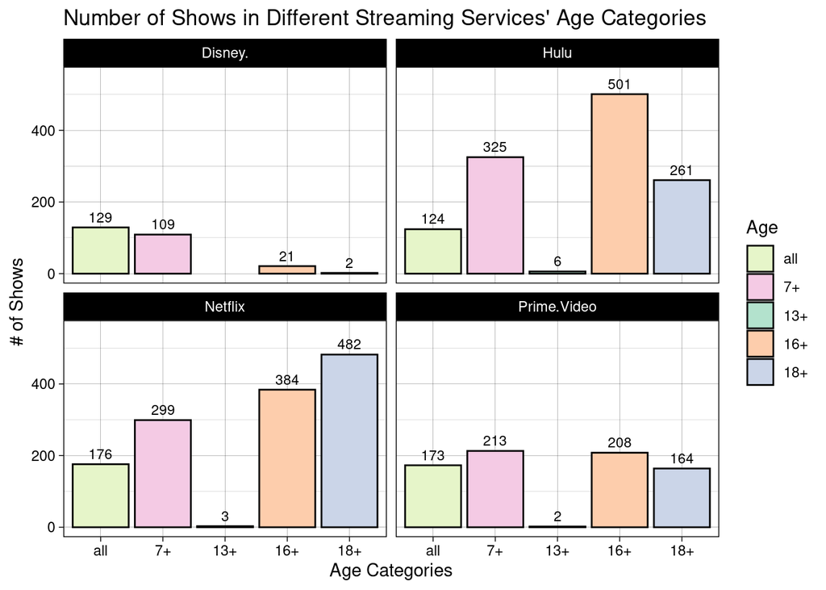

```r
streamingdata_ %>%
  ggplot(aes(Age, fill = Age)) +
  geom_bar(colour = "black") +
  facet_wrap(~Service) +
  scale_x_discrete(limits = c("all", "7+", "13+", "16+", "18+")) +
  geom_text(aes(label = after_stat(count)), stat = "count", colour = "black", vjust = -.5, size = 3) +
  ylim(0,550) +
  labs(title = "Number of Shows in Different Streaming Services' Age Categories",
       x = "Age Categories",
       y = "# of Shows") +
  scale_fill_brewer(palette = "Pastel2", breaks = c("all", "7+", "13+", "16+", "18+")) +
  theme_linedraw()
```

## Questions

**Question 1:** Based on your plots, make five informational statements or comparisons regarding the Disney+ streaming service.

**Question 2:** What other data would you like to have, or which existing variables would you like to see transformed, if you were going to do further explorations or visualizations? Give at least two examples.

**ANSWER**

I would like to see the engagement of viewers when analyzing the ratings for the different services. It would be interesting to know the how long the viewers watched movie before writing a review or how many episodes of a show the watched before writing a review. It would also be interesting to analyze the demographics of the viewers and see how age/gender/country relate to service preferences, genre of movies/shows, and ratings. It could aslo be fun to see how a directors with multiple movies are rated and if the service has any affect.

**Question 3:** Explain the rationale behind the choices you made with regard to plot type, formatting, and so on, when you created Analysis 4. What motivated your decisions with regard to this plot?

**ANSWER**

For Analysis 4, I created a plot of the quantity of shows of certain age categories factored by the different streaming services. I wanted to look at this data because I was curious about the target audiences for each service. Most people I know subscribe to all four, but I can only afford one right now. Since I tend to like shows in the 16-18+ range, Hulu or Netflix would be a good investment.